# Ford GoBike System Data

## by Sertaç Özker

## Investigation Overview

> I would like to give an overall look into Ford GoBike System. Our presentation will be mostly over visualizations.

## Dataset Overview

> The dataset is downloaded from https://s3.amazonaws.com/baywheels-data/index.html as seperate months and other dates are available. I will focus on the first 10 months of 2019 data. Sadly our data does not contain any information about the users. Therefore we had to focus on the usage of the system.

## Trip Duration

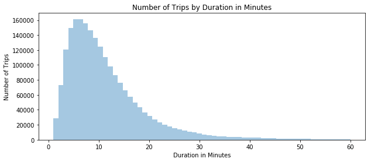

```python
import seaborn as sns

plt.figure(figsize=(10,4))
sns.distplot(df[df['duration_min']<60]['duration_min'], kde=False, bins=60)
plt.title("Number of Trips by Duration in Minutes")
plt.xlabel('Duration in Minutes')
plt.ylabel('Number of Trips');
plt.show()
```

## User Types

> Big percent of the trips are done by the subscribers.

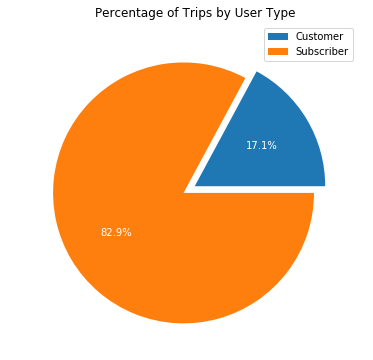

```python
total_trips = df['duration_sec'].count()
customer_trips = df[df['user_type']=='Customer']['duration_sec'].count() / total_trips
subscriber_trips = df[df['user_type']=='Subscriber']['duration_sec'].count() / total_trips

plt.figure(figsize=(6,6))
plt.pie([customer_trips,subscriber_trips], explode=(0, 0.1), labels=['Customer', 'Subscriber'],
        autopct='%1.1f%%', startangle=0, textprops={'color':'white'})
plt.title("Percentage of Trips by User Type")
plt.legend()
plt.show()
```

## Usage Statistics

> If we check the number of trips seperated by Weekdays and Weekends, we can, clearly see that bike sharing program is used for commuting purposes mostly.

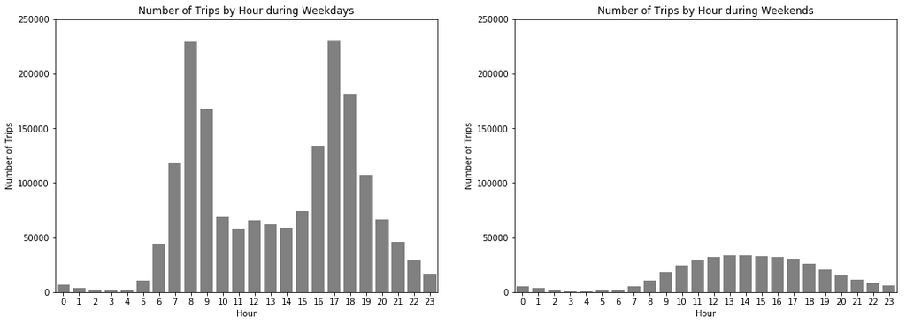

```python
plt.figure(figsize=(18,6))

plt.subplot(1, 2, 1) # 1 row, 2 cols, subplot 1
fig1 = sns.countplot(x='start_time_hour',data=df[df['week_period']=='Weekday'], color='Grey')
plt.title("Number of Trips by Hour during Weekdays")
plt.xlabel('Hour')
plt.ylabel('Number of Trips')
plt.ylim([0,250000])


plt.subplot(1, 2, 2) # 1 row, 2 cols, subplot 1
fig1 = sns.countplot(x='start_time_hour',data=df[df['week_period']=='Weekend'], color='Grey')
plt.title("Number of Trips by Hour during Weekends")
plt.xlabel('Hour')
plt.ylabel('Number of Trips')
plt.ylim([0,250000])
plt.show()
```

## Trip Durations

> This shows that people take longer trips during weekends.

> Shortest trips are done during weekdays at early rush hour when people are going to work. We don't see this pattern in the evenings. Maybe people are more energetic in the early hours and the traffic congestion is low, alloing them to reach their destinations faster.

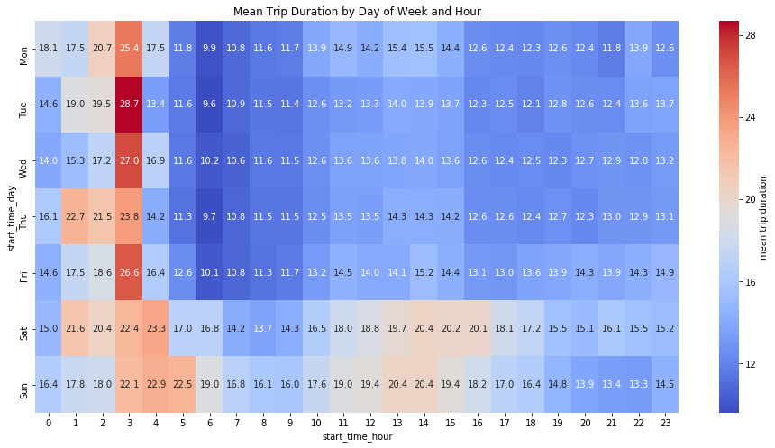

```python
data = pd.DataFrame(df.groupby(['start_time_day', 'start_time_hour']).mean()['duration_min'])
data = data.reset_index()
data.start_time_day = pd.Categorical(data.start_time_day,
                      categories=['Mon', 'Tue', 'Wed', 'Thu', 'Fri', 'Sat', 'Sun'],
                      ordered=True)

pivot = data.pivot_table(values='duration_min',index='start_time_day',columns='start_time_hour')
plt.figure(figsize=(16,8))
sns.heatmap(pivot, annot=True, fmt='.1f', cbar_kws = {'label' : 'mean trip duration'}, cmap='coolwarm')
plt.title("Mean Trip Duration by Day of Week and Hour")
```

## Coverage in Bay Area

> The application is used all around San Francisco Bay Area. It's mostly used places around the Financial District.

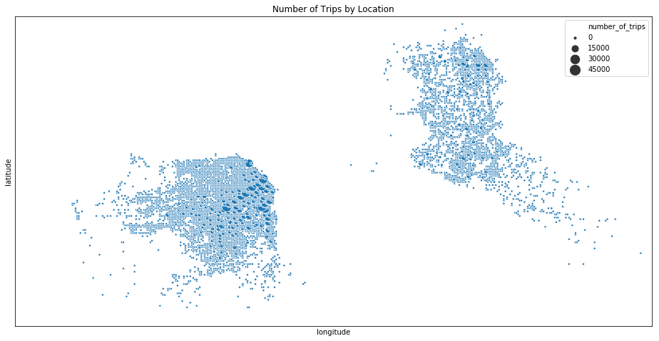

```python
data = df.copy()
data['start_station_latitude'] = data.start_station_latitude.round(3)
data['start_station_longitude'] = data.start_station_longitude.round(3)
data = pd.DataFrame(data.groupby(['start_station_latitude', 'start_station_longitude']).count()['duration_min'])
data = data.reset_index()
data.rename(columns={"start_station_latitude": "latitude",
                     "start_station_longitude": "longitude",
                     "duration_min": "number_of_trips"}, inplace=True)
data['longitude'] = data['longitude']+180

plt.figure(figsize=(16,8))
sns.scatterplot(x="longitude", y="latitude", size="number_of_trips", sizes=(10, 200), data=data)
plt.ylim(37.7,37.9)
plt.xlim(57.45,57.85)
plt.title("Number of Trips by Location")
plt.yticks([])
plt.xticks([])
plt.legend()
```